# Trabalho 2

Felipe Pereira/João Dias

27/10/2024

## Pergunta 1

Os métodos de validação cruzada são técnicas de reamostragem usadas para quantificar erros de estimação e avaliar a qualidade de previsão de modelos. Estes métodos dividem uma amostra original em dois subconjuntos: o conjunto de treino, que serve para ajustar o modelo, e o conjunto de teste, usado para avaliar a precisão da previsão. Os principais tipos de validação cruzada são:

1. **Leave-One-Out (n-fold)**: Cada observação é usada uma vez como teste enquanto as demais compõem o treino. Isso gera n modelos diferentes, um para cada exclusão. A média dos erros de previsão é calculada para avaliar o modelo.
2. **K-fold**: A amostra é dividida em K subconjuntos (ou *folds*). Em cada rodada, um dos folds é usado para teste enquanto os restantes K-1 são usados para treino. Ao final, calcula-se a média dos erros de previsão de cada rodada, oferecendo um balanço entre o viés e a variância.

Ambos métodos permitem comparar o desempenho de modelos concorrentes, selecionando aquele com menor erro quadrático médio.

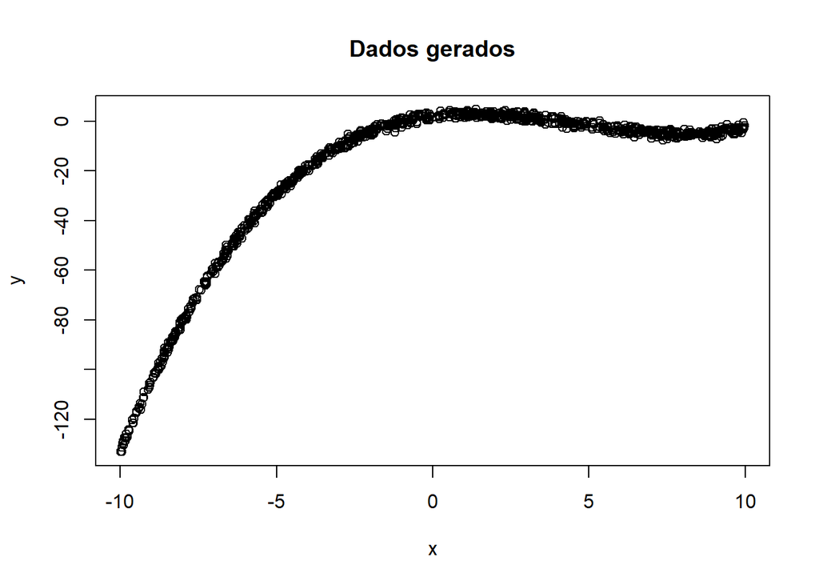

```r
set.seed(110305)

funcao_geradora_dos_dados <- function(n, ruido){
  x <- runif(n, -10, 10)
  y <- 2 + 1.5 * x - 0.7 * x^2 + 0.05 * x^3 + rnorm(n, mean = 0, sd = ruido)
  data.frame(x = x, y = y)
}

dados <- funcao_geradora_dos_dados(n = 1000, ruido = 1)
plot(dados$x, dados$y, main = "Dados gerados", xlab = "x", ylab = "y")
```

## Pergunta 2

```r
# Modelo de regressão linear simples
modelo_linear <- lm(y ~ x, data = dados)

# Modelo de regressão polinomial de terceiro grau
modelo_polinomial <- lm(y ~ x + I(x^2) + I(x^3), data = dados)

# Coeficientes dos modelos
print("Coeficientes do modelo linear:")
```

```
## [1] "Coeficientes do modelo linear:"
```

```r
print(coef(modelo_linear))
```

```
## (Intercept)           x
##  -20.663012    4.337129
```

```r
print("Coeficientes do modelo polinomial:")
```

```
## [1] "Coeficientes do modelo polinomial:"
```

```r
print(coef(modelo_polinomial))
```

```
## (Intercept)           x      I(x^2)      I(x^3)
##  1.96079894  1.50414732 -0.69882244  0.04996198
```

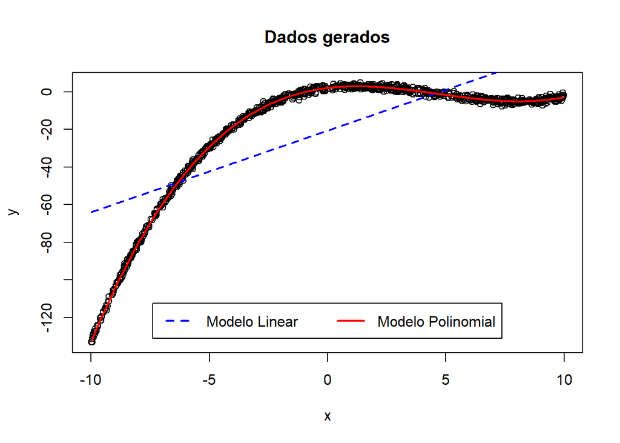

```r
# Adicionar as previsões ao gráfico
x_seq <- seq(min(dados$x), max(dados$x), length.out = 1000)
y_pred_linear <- predict(modelo_linear, newdata = data.frame(x = x_seq))
y_pred_polinomial <- predict(modelo_polinomial, newdata = data.frame(x = x_seq))

plot(dados$x, dados$y, main = "Dados gerados", xlab = "x", ylab = "y")
lines(x_seq, y_pred_linear, col = "blue", lwd = 2, lty = 2)  # Modelo Linear
lines(x_seq, y_pred_polinomial, col = "red", lwd = 2)        # Modelo Polinomial
legend("bottom", legend = c("Modelo Linear", "Modelo Polinomial"),
       col = c("blue", "red"), lty = c(2, 1), lwd = 2, horiz = TRUE, inset = 0.05)
```

### Descrição dos Modelos

**Regressão Linear Simples (modelo_linear)**: Este modelo assume uma relação linear entre a variável independente x e a variável dependente y. No contexto do problema, o modelo linear é da forma:

$y = \beta_0 + \beta_1 x + \epsilon$

Aqui, \( \beta_0 \) representa a intersecção, \( \beta_1 \) é o declive, e \( \epsilon \) representa o erro aleatório. A regressão linear simples é geralmente fácil de interpretar, mas, como neste caso os dados foram gerados com um componente polinomial, já antecipamos que este modelo possa não ser o mais adequado para capturar a complexidade da relação entre as variáveis.

**Regressão Polinomial de Terceiro Grau (modelo_polinomial):**

\(y = \beta_0 + \beta_1 x + \beta_2 x^2 + \beta_3 x^3 + \epsilon\)

Aqui, \( \beta_2 \) e \( \beta_3 \) são coeficientes adicionais que permitem modelar a relação entre \( x \) e \( y \) como uma curva de terceiro grau. Este modelo pode ajustar-se melhor aos dados gerados, pois a função de geração inclui termos quadráticos e cúbicos.

## Pergunta 3

```r
library(cvTools)
# Definir os números de folds para análise
folds_list <- c(5, 10, 20, 50)
set.seed(110305)

# Função para calcular o MSE usando a validação cruzada
calcula_mse <- function(folds) {
  dados <- funcao_geradora_dos_dados(n = 1000, ruido = 1)

  # Definir os grupos de validação cruzada
  grupos <- cvFolds(nrow(dados), K = folds, R = 1)

  # Ajustar os modelos
  modelo_linear <- lm(y ~ x, data = dados)
  modelo_polinomial <- lm(y ~ x + I(x^2) + I(x^3), data = dados)

  # Calcular MSE para cada modelo
  cv_linear <- cvLm(modelo_linear, cost = mspe, folds = grupos, seed = 110305)$cv
  cv_polinomial <- cvLm(modelo_polinomial, cost = mspe, folds = grupos, seed = 110305)$cv

  return(c(cv_linear, cv_polinomial))
}

# Aplicar a função para diferentes números de folds
resultados <- t(sapply(folds_list, calcula_mse))
colnames(resultados) <- c("MSE Linear", "MSE Polinomial")
rownames(resultados) <- paste("Folds =", folds_list)

resultados
```

```
##            MSE Linear MSE Polinomial
## Folds = 5    475.2206      0.9553387
## Folds = 10   474.3617      0.9607773
## Folds = 20   475.1497      0.9608242
## Folds = 50   474.3240      0.9602882
```

## Pergunta 4

Ao comparar os dois modelos, a diferença significativa entre os MSE indica claramente que o modelo polinomial é preferível em termos de ajuste aos dados, enquanto o modelo linear apresenta um desempenho insatisfatório, com um erro muito elevado. A evolução dos MSE do modelo polinomial em relação ao número de folds é relativamente estável, mostrando que, mesmo ao aumentar a complexidade da validação cruzada, este modelo mantém um desempenho robusto.

No que diz respeito ao tradeoff entre variância e viés, o modelo linear, com o seu alto MSE, provavelmente sofre de viés alto e variância baixa, pois não consegue capturar adequadamente a relação entre as variáveis. Em contraste, o modelo polinomial, com o seu MSE baixo, sugere um melhor equilíbrio entre viés e variância, indicando que ele consegue ajustar-se bem aos dados, evitando o overfitting ao mesmo tempo.